# 08_kadai

作者

24110016

```r
# 50%を基準にチームの戦術スタイルをカテゴリ化
analysis_data3 <- analysis_data |>
  mutate(Poss_Style = if_else(Poss >= 50, "50%以上 (保持型)", "50%未満 (非保持型)"))
```

```r
#グループ別集計
poss_summary <- analysis_data3 |>
  group_by(Poss_Style) |>
  summarise(
    試合数 = n(),
    勝率 = mean(win, na.rm = TRUE)
)
print(poss_summary)
```

```
# A tibble: 2 × 3
  Poss_Style         試合数  勝率
  <chr>               <int> <dbl>
1 50%以上 (保持型)      394 0.266
2 50%未満 (非保持型)    366 0.486
```

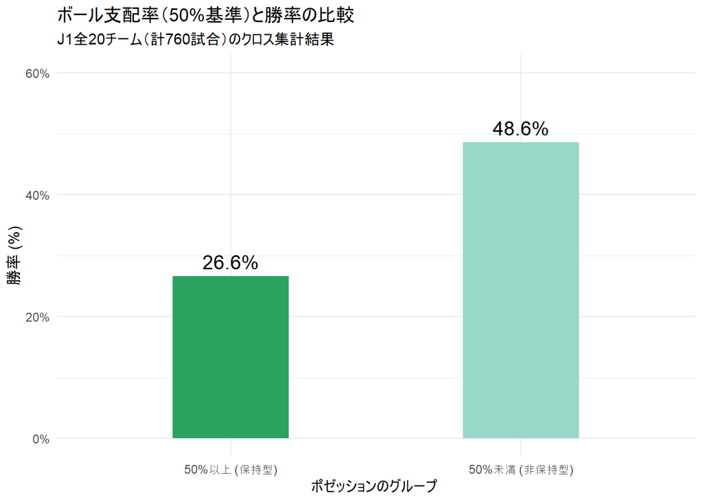

```r
ggplot(poss_summary, aes(x = Poss_Style, y = 勝率, fill = Poss_Style)) +
  geom_col(width = 0.4, show.legend = FALSE) +
  # 棒の上に勝率の％を表示
  geom_text(aes(label = paste0(round(勝率 * 100, 1), "%")), vjust = -0.5, size = 5) +
  scale_y_continuous(labels = scales::percent, limits = c(0, 0.6)) +
  scale_fill_manual(values = c("50%以上 (保持型)" = "#2ca25f", "50%未満 (非保持型)" = "#99d8c9")) +
  labs(
    title = "ボール支配率（50%基準）と勝率の比較",
    subtitle = "J1全20チーム（計760試合）のクロス集計結果",
    x = "ポゼッションのグループ ",
    y = "勝率 (%)"
  ) +
  theme_minimal(base_family = "HiraKakuProN-W3")
```

・ボール支配率を50%を基準に分類した結果、50%以上（保持型：394試合）の勝率が26.6%にとどまったのに対し、50%未満（非保持型：366試合）の勝率は48.6%を記録し、大きな差が見られた

・ボールを保持する側が相手の守備ブロックを崩しきれずに攻めあぐねる一方で、ボールを持たない側が組織的な守備から効率よくカウンターを決めて勝利している構図を示している

・現在のJリーグにおいては「ボールを保持する展開」よりも、あえて支配率を低く抑えて戦う「堅守速攻型の展開」の方が、統計的に圧倒的に高い勝利への有効性（優位性）を持っていると言える

```r
# 1. ロジスティック回帰分析の実行 (glm関数を使い、family = binomial を指定する)
logistic_model <- glm(win ~ Poss, data = analysis_data, family = binomial)

# 2. 分析結果のサマリーを表示
summary(logistic_model)
```

```
Call:
glm(formula = win ~ Poss, family = binomial, data = analysis_data)

Coefficients:
             Estimate Std. Error z value Pr(>|z|)
(Intercept)  1.322265   0.369591   3.578 0.000347 ***
Poss        -0.037251   0.007379  -5.048 4.46e-07 ***
---
Signif. codes:  0 '***' 0.001 '**' 0.01 '*' 0.05 '.' 0.1 ' ' 1

(Dispersion parameter for binomial family taken to be 1)

    Null deviance: 1003.51  on 759  degrees of freedom
Residual deviance:  976.89  on 758  degrees of freedom
AIC: 980.89

Number of Fisher Scoring iterations: 4
```

```r
# 3. 【超重要】オッズ比の計算（レポートで必須になる数値）
# 係数を指数関数（exp）に変換して、確率の変化をわかりやすくします
odds_ratios <- exp(coef(logistic_model))
print("--- オッズ比 (Odds Ratios) ---")
```

```
[1] "--- オッズ比 (Odds Ratios) ---"
```

```r
print(odds_ratios)
```

```
(Intercept)        Poss
  3.7519087   0.9634338
```

勝敗を目的変数、ボール支配率（Poss）を説明変数としたロジスティック回帰分析を行った結果、P値が 4.46e-07 となり、有意水準5%において統計的に極めて有意な負の影響（-0.037）を与えていることが判明しました。

算出されたオッズ比は 0.963 であり、これは「ボール支配率が1%高くなるごとに、勝利する見込み（オッズ）が約 3.7% ずつ減少する」という具体的な確率への悪影響を示しています。

結論として、現在のJリーグにおいてはボールを保持して主導権を握るスタイルよりも、あえてボールを手放して戦う方が統計的に明らかに勝利しやすいという「ポゼッションの罠（またはカウンター戦術の有効性）」が、回帰モデルからも明確に実証されました。